# Text as Data: Vector Space Models

Robert Stine

July 2017

This notebook illustrates the use of vector space methods in R. These manipulate the document-term matrix and can be used to find *word embeddings*. ]

# Setup R

The methods in this notebook add another package to the standard list.

```r
require(tm)
require(wordcloud)
require(stringr)        # not in the tidyverse
require(tidyverse)
source("text_utils.R")  # from web page
```

# Prepare document-term matrix

Read the wine data from its CSV file. Rather than do this every time, it is generally a good idea to save the “processed” data in a “.sav” file.

```r
Wine <- read_csv("../data/Wine.csv", col_types = cols(alcohol = col_double()))
dim(Wine)
```

```
[1] 20508    14
```

```r
WineCorpus <- Corpus(VectorSource(Wine$description))
replace <- content_transformer(function(text, from, to) str_replace_all(text, from, to))
toSpace <- content_transformer(function(text, pattern) str_replace_all(text, pattern, " "))
toLower <- content_transformer(function(text) tolower(text))
WineCorpus <- tm_map(WineCorpus, toLower)
WineCorpus <- tm_map(WineCorpus, replace, "wieght", "weight")
WineCorpus <- tm_map(WineCorpus, toSpace, '-|/|,|\\.')     # otherwise runs together; dot is special regex
WineCorpus <- tm_map(WineCorpus, removePunctuation)
WineCorpus <- tm_map(WineCorpus, stripWhitespace)
# WineCorpus <- tm_map(WineCorpus, removeWords, stopwords("english"))  # leave for now
```

Now compute the document term matrix and the row `ni` and column `mj` marginal counts. The DTM is a little smaller, with fewer types – 5,488 – here than in the first slides because of handling the comma differently. We will be making it smaller still.

```r
dtm <- DocumentTermMatrix(WineCorpus)
dtm
```

```
<<DocumentTermMatrix (documents: 20508, terms: 5488)>>
Non-/sparse entries: 545777/112002127
Sparsity           : 100%
Maximal term length: 15
Weighting          : term frequency (tf)
```

```r
ni <- rowSums(as.matrix(dtm))
mj <- colSums(as.matrix(dtm))
word.types <- names(mj)   # for convenience and clarity
```

As usual, check the name of the longest type for possible errors. This one is okay.

```r
word.types[j <- which.max(str_length(word.types))]
```

```
[1] "extraordinarily"
```

```r
sum(as.matrix(dtm))
```

```
[1] 607355
```

```r
sum(mj)
```

```
[1] 607355
```

```r
sum(ni)
```

```
[1] 607355
```

Many tokens represents rare types.

```r
sum(mj==1)
```

```
[1] 1827
```

```r
sum(mj==2)
```

```
[1] 660
```

```r
sum(mj==3)
```

```
[1] 367
```

```r
sum(mj[3<mj])
```

```
[1] 603107
```

```r
sum(mj[mj<=3])
```

```
[1] 4248
```

`tm` has the function `findFreqTerms` to extract the most frequent terms in the DTM (not that this is hard to do directly). Start with a high treshold to avoid too many.

```r
findFreqTerms(dtm,lowfreq=5000)
```

```
 [1] "and"      "aromas"   "bodied"   "dry"      "finish"   "medium"   "palate"   "with"
 [9] "acidity"  "cherry"   "entry"    "fruit"    "full"     "leads"    "tannins"  "this"
[17] "apple"    "fruity"   "finishes" "body"     "fade"
```

Bar charts are easy to construct. This one shows the “Zipf” relationshiop rather clearly (at least when the stop words have been included). The function `tibble` constructs a tidy data frame.

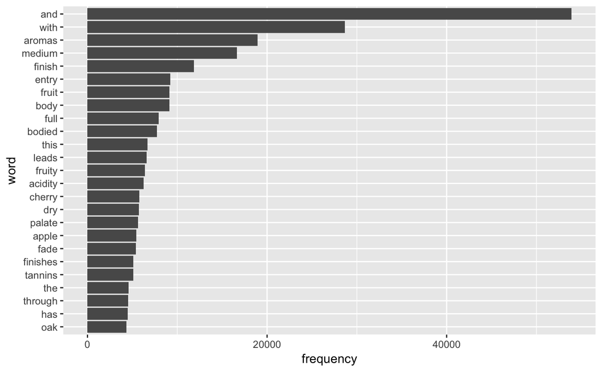

```r
tibble(word=names(mj), frequency=mj)      %>%
    top_n(25,frequency)                   %>%
    mutate(word=reorder(word, frequency)) %>%
    ggplot(aes(word,frequency)) +
    geom_col() + coord_flip()
```

You can also draw word clouds to summzarize the most common types; eye candy can be useful to attract attention (though it makes it difficult to compare the frequencies… quick, which is the 5th most common word). Don’t try to show too many words. Removing stop words would be very useful in this case.

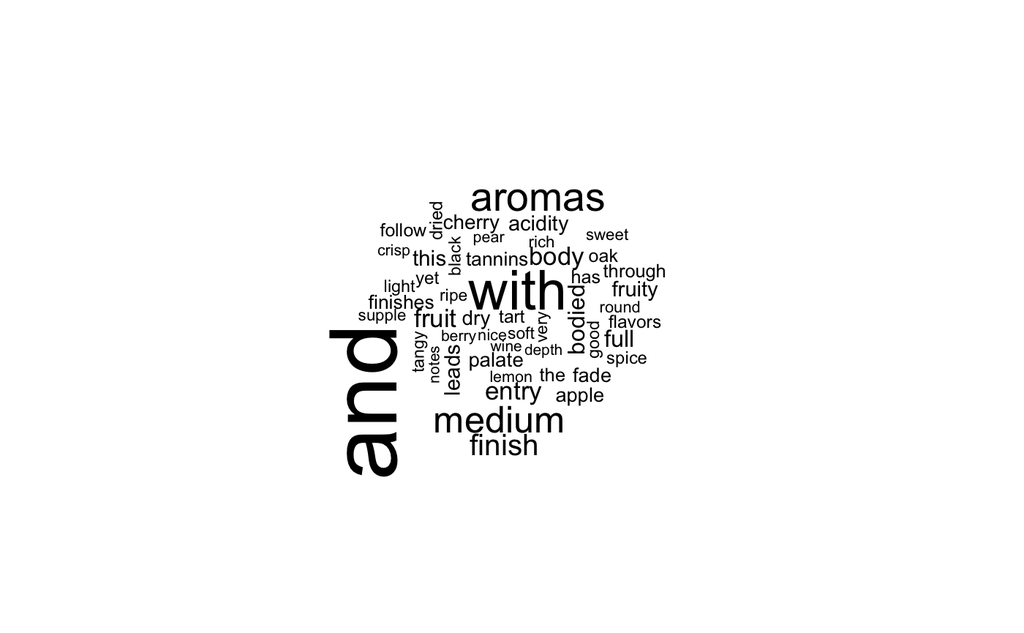

```r
require(wordcloud)
set.seed(133)  # random locations; fix the seed to be able to reproduce
wordcloud(names(mj), mj, max.words=50)
```

The function `zipf_plot` from the helper file ${\tt text\_utils.R}$ shows the Zipf plot. By default, it fits a least squares lines to the first 250 frequencies.

```
Call:
lm(formula = ly ~ lx, data = df[1:min(n.fit, nrow(df)), ])

Coefficients:
(Intercept)           lx
    11.2897      -0.9475
```

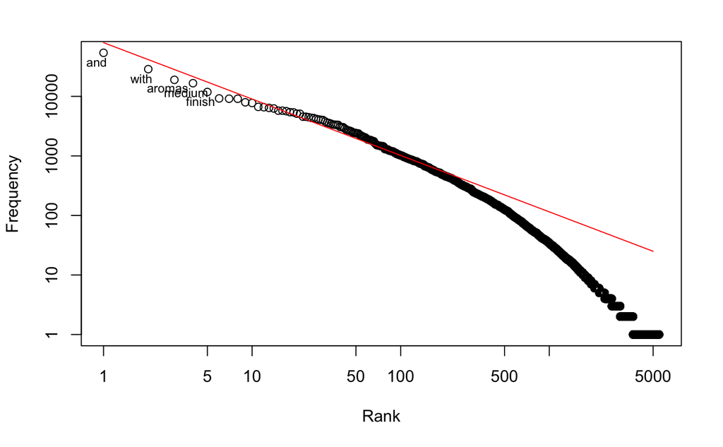

```r
zipf_plot(mj)
```

# Handling rare words

Spectral methods rely on word co-occurences within some context. The context might be defined by adjacency (bigrams, n-grams) or, in this case, appearing in the same wine review. To make it simpler to find the common types from the rare types, sort the DTM by the type frequencies. This calculation uses the function `order`. Here’s an example. `order` returns the indices that will sort an object.

```r
x <- c('d','f','a','c','b')
o <- order(x); o
```

```
[1] 3 5 4 1 2
```

```r
x[o]
```

```
[1] "a" "b" "c" "d" "f"
```

Now apply `order` to the frequencies of the word types.

```r
o <- order(mj, decreasing=TRUE)   # biggest to smallest
dtm <- dtm[,o]                    # permute the columns
mj <- mj[o]
```

Now the first types are the most common types.

```r
mj[1:10]
```

```
   and   with aromas medium finish  entry  fruit   body   full bodied
 53906  28665  18956  16635  11835   9235   9136   9117   7950   7741
```

Here are some of the smaller types. If you explore the less common types, you will discover a mixture of interesting words (given that these are wine reviews) along with some junk (such as misspelled words, typos, numbers, and dates).

```r
mj[length(mj)-9:0]
```

```
  uniquely   covereed    picatta      sodas   withered      verde      vinho colossally    utility
         1          1          1          1          1          1          1          1          1
      mary
         1
```

We are not going to learn much about the usage of words that appear so seldom, so set these all to the symbol OOV, short for out-of-vocabulary. We don’t need to do that in the text itself, just in the document term matrix. I will keep the types that appear at least 10 times (as JMP used). That reduces the matrix to 1,742 types. (BTW, `tm` includes the function `removeSparseTerms` that will wipe out the rare terms from the DTM. I don’t want to wipe them out; I want to consolidate them.)

```r
dtm.oov <- dtm[,10 <= mj]
dtm.oov
```

```
<<DocumentTermMatrix (documents: 20508, terms: 1742)>>
Non-/sparse entries: 536404/35188532
Sparsity           : 98%
Maximal term length: 15
Weighting          : term frequency (tf)
```

Now what to do about the OOVs. Maybe having a lot of them tells us something about the other words? I’ll append a column that includes the number of these in each document. Doing so turns the document-term matrix into a regular numerical matrix, but that’s okay – we need such a matrix for computing the SVD.

```r
dtm.oov <- cbind(as.matrix(dtm.oov), rowSums(as.matrix(dtm[,mj < 10])))
dim(dtm.oov)
```

```
[1] 20508  1743
```

```r
names.oov  <- c(names(mj[10<=mj]), 'OOV')
mj.oov <- c(mj[10<=mj],sum(mj[mj<10]))
ni.oov <- ni                            # the same as it was
colnames(dtm.oov) <- names.oov
names(mj.oov) <- names.oov
```

Now check we have not lost any terms.

```r
sum(dtm.oov)
```

```
[1] 607355
```

```r
sum(mj.oov)
```

```
[1] 607355
```

```r
sum(ni.oov)
```

```
[1] 607355
```

# Singular value decomposition and latent semantic analysis

We will need a regular R matrix in the following calculations, so convert a special sparse matrix of counts into a regular R matrix using `as.matrix`. The matrix `dtm.oov` is already in the needed form.

The SVD and latent semantic analysis rely on associations of words in documents: which words appear together in the same document. We can look at correlations individually to see what sort of information lies in these associations. We can explore the associations between word types with the `tm` function `findAssoc`.

```r
findAssocs(dtm,'zinfandel', corlimit=0.1)
```

```
$zinfandel
      creek      pushed unashamedly    heavenly   slathered      fetzer    mesquite        wire
       0.25        0.14        0.14        0.14        0.14        0.14        0.14        0.14
    marsala   spareribs   raspberry    textbook   accompany
       0.12        0.12        0.11        0.11        0.10
```

```r
findAssocs(dtm,'pinot', corlimit=0.1)
```

```
$pinot
    noir   grigio     gris   oregon     duck cardamom  russian      fin    noirs    found   breast
    0.64     0.33     0.29     0.17     0.15     0.13     0.13     0.12     0.12     0.12     0.11
    tuna      coq
    0.10     0.10
```

Paso Robles is a place, so the two words “paso” and “robles” always occur together. Hence, the correlation of these types is 1.

```r
findAssocs(dtm,'paso', corlimit=0.1)
```

```
$paso
    robles    central    venison  casserole  spareribs      south underrated       such    monster
      1.00       0.29       0.22       0.22       0.21       0.20       0.18       0.17       0.16
    breast california  accompany     region    blended      goose       from    cheddar    marsala
      0.14       0.13       0.13       0.12       0.12       0.12       0.11       0.11       0.10
      buco
      0.10
```

Before computing the singular value decomposition (SVD), it is a good idea to do some normalization. The “correct” normalization is rather time consuming (requiring the *inverse* of a large matrix, which is tough to do in big-data situations), but the following approximation works nicely in practice.

The calculation of the SVD itself is also rather slow. It’s a simple function call in R, but one that takes a very long time to complete. In the interest of time, we’ll compute the SVD using a subset of 3,000 documents. In a bit, I will show you a magic trick that scales better.

```r
set.seed(2373)                         # so can reproduce
i.svd <- sample(nrow(dtm.oov), 3000)
dtm.svd <- dtm.oov[i.svd,]
ni.svd <- rowSums(dtm.svd)                # number of words in a document, its length
mj.svd <- pmax(1,colSums(dtm.svd))        # frequency of word type in vocabulary (avoid 0 divisor)
```

The minimum frequency in the original DTM is 10.

```r
min(mj.oov)
```

```
[1] 10
```

After sampling, however, it sometimes is zero. (That’s why `pmax` is used above… we don’t want a zero divisor.)

```r
min(mj.svd)                               # even though we started with at leat
```

```
[1] 1
```

This normalization is *almost* a standardization to correlations… but a lot faster.

```r
dtm.svd <- dtm.svd/sqrt(ni.svd)               # take advantage of R behavior
dtm.svd <- t( t(dtm.svd)/sqrt(mj.svd) )
```

Now we can compute the SVD of the scaled matrix of counts, $C_{ij}/\sqrt{n_i m_j}$.

```r
udv <- svd(dtm.svd)                 # returns u, d, v
names(udv)
```

```
[1] "d" "u" "v"
```

```r
length(udv$d)                       # singular values
```

```
[1] 1743
```

```r
udv$d[1:4]                          # normalization implies first = 1
```

```
[1] 1.0000000 0.6448068 0.5553221 0.4768119
```

Remember to combine variables in order to use `ggplot`.

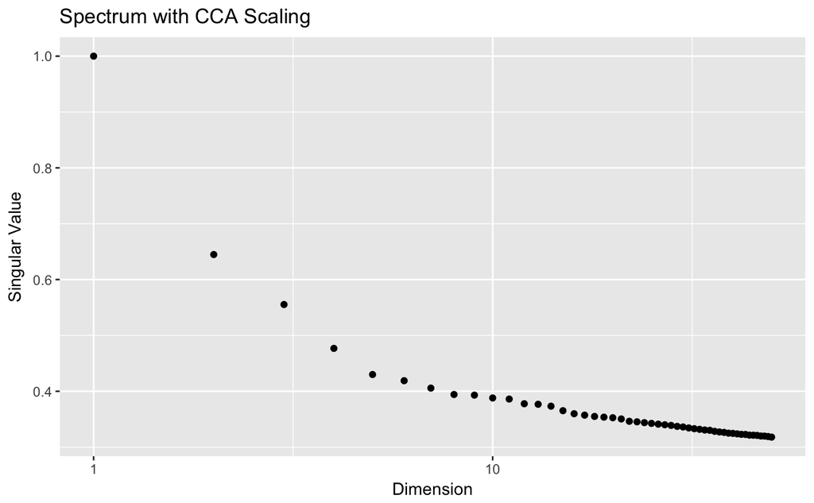

```r
tibble(i=1:50, d=udv$d[1:50]) %>%
    ggplot(aes(i,d)) +
    geom_point() + scale_x_log10() +
    labs(title="Spectrum with CCA Scaling",  x="Dimension", y="Singular Value")
```

The rows of the $U$ matrix identify documents, so think of these as “new variables” that describe the documents. The rows of $V$ identify word types and so provide an “interpretation” of the $U_j$ columns. The elements of $U$ sometimes reveal clusters of related documents, whereas the elements of $V$ reveal the components of these new variables.

As is regular principal components analysis, the first component in these data captures the number of words (which happens to be an important variable in the wine analysis).

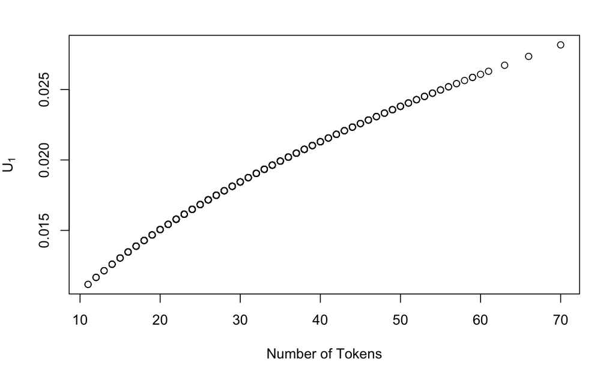

```r
plot(ni[i.svd], udv$u[,1], xlab="Number of Tokens", ylab=expression("U"[1]))
```

In this example, clusters are easy to see. I don’t like the various alternatives to `pairs` offered by the Tidy collection, so its back to regular R graphics. (Why not: suppose I don’t want the colors to be shown in the matrix of plots, or I’d like to use expressions to label the variables?)

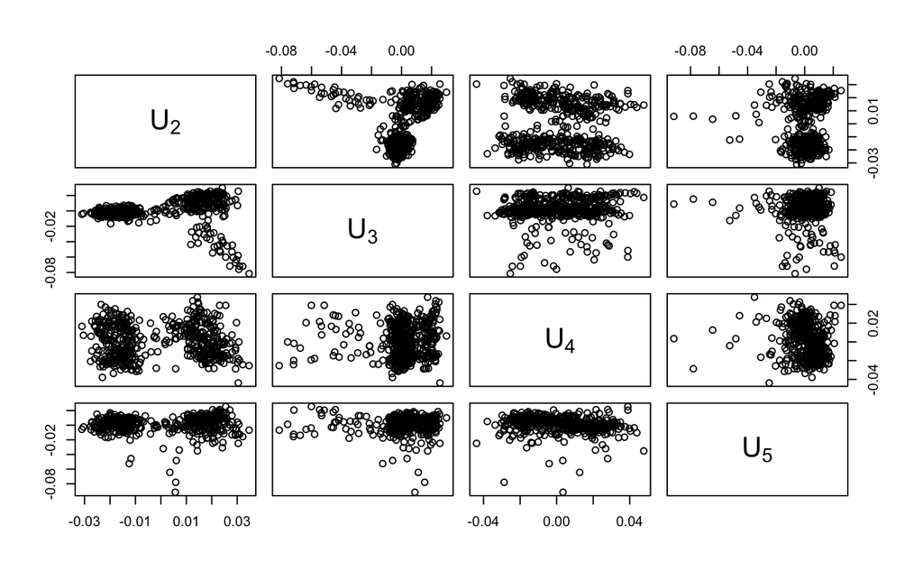

```r
set.seed(234)
ii <- sample(nrow(udv$u), 500)   # fewer points
pairs(udv$u[ii,2:5],
      labels=c(expression("U"[2]), expression("U"[3]),  # subscripts in plot label
               expression("U"[4]), expression("U"[5]))  )
```

It would be neat if those clusters were associated with the colors of the wines. The following plot shows that is not the case.

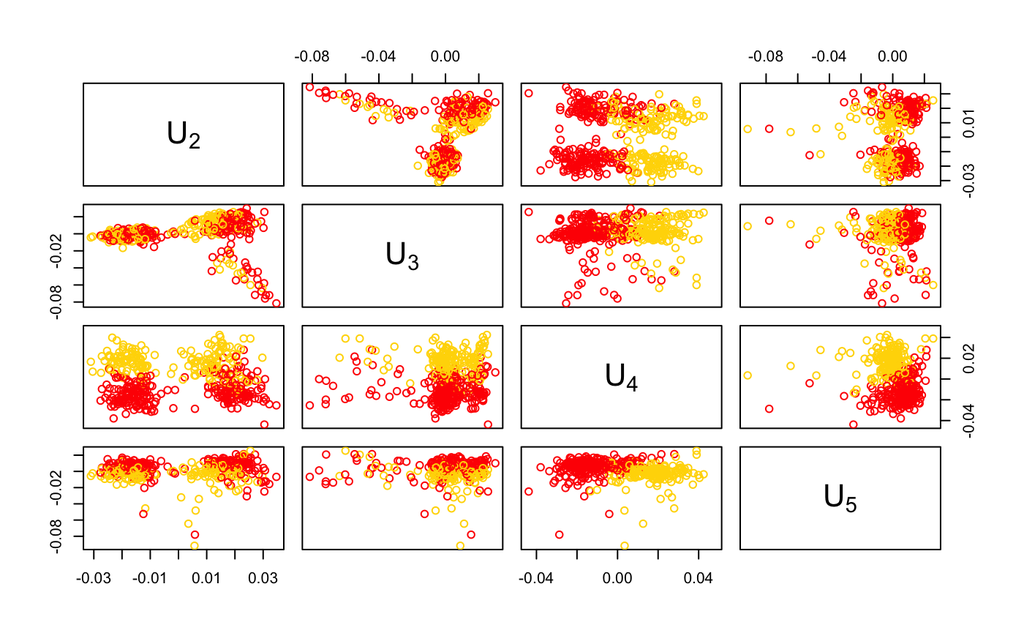

```r
color <- tolower(Wine$color[i.svd][ii])
color[color=='white'] <- 'gold'           # white does not show up well!
pairs(udv$u[ii,2:5], col=color,
      labels=c(expression("U"[2]), expression("U"[3]),  # subscripts in plot label
               expression("U"[4]), expression("U"[5]))  )
```

Although the obvious clusters defined by these new variables do not correspond to the wine color, it is easy to see how we can use $U_4$ and perhaps $U_5$ to separate red from white wines. Rather than speculate, we can simply fit a logistic regression.

```r
j <- 1:10
U   <- udv$u[,j]
y   <- ifelse(Wine$color[i.svd] == 'Red',1,0)
lregr <- glm(y ~ U, family=binomial, na.action=na.exclude)
summary(lregr)
```

```
Call:
glm(formula = y ~ U, family = binomial, na.action = na.exclude)

Deviance Residuals:
    Min       1Q   Median       3Q      Max
-3.1499  -0.0343   0.0038   0.0726   3.2551

Coefficients:
             Estimate Std. Error z value Pr(>|z|)
(Intercept)   -0.6021     1.3334  -0.452  0.65161
U1            90.0483    74.8393   1.203  0.22889
U2            -2.3739     7.9956  -0.297  0.76655
U3           -29.9632     6.7501  -4.439 9.04e-06 ***
U4          -383.3268    23.3412 -16.423  < 2e-16 ***
U5            81.7788    14.9954   5.454 4.94e-08 ***
U6           157.3792    10.9946  14.314  < 2e-16 ***
U7           -18.7985     7.2497  -2.593  0.00951 **
U8            89.7537    11.2374   7.987 1.38e-15 ***
U9            59.7435     8.9418   6.681 2.37e-11 ***
U10          -16.9630    12.4151  -1.366  0.17184
---
Signif. codes:  0 ‘***’ 0.001 ‘**’ 0.01 ‘*’ 0.05 ‘.’ 0.1 ‘ ’ 1

(Dispersion parameter for binomial family taken to be 1)

    Null deviance: 3441.04  on 2539  degrees of freedom
Residual deviance:  421.57  on 2529  degrees of freedom
  (460 observations deleted due to missingness)
AIC: 443.57

Number of Fisher Scoring iterations: 9
```

These predictions separate the wine types nicely.

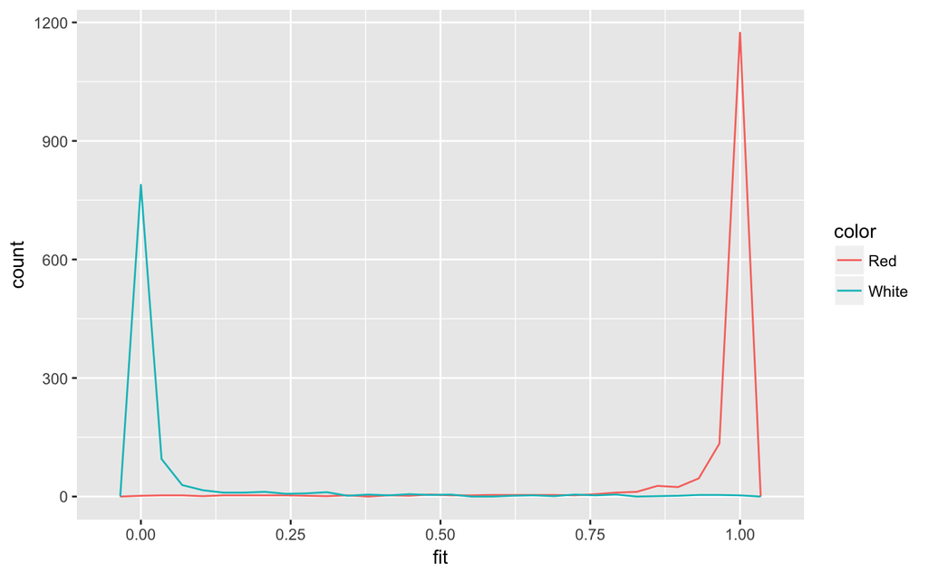

```r
data_frame(fit=fitted.values(lregr), color=Wine$color[i.svd]) %>%
    ggplot(aes(x=fit,color=color)) + geom_freqpoly()
```

But what are these variables that so clearly separate the wines? Once you see the names of the components of $V_4$ it becomes clear why this variable works to separate the two types of wines.

First attach names. Notice that the names of the *rows* of $V$ match the names of the columns of $C$, the document term matrix.

```r
V <- udv$v[,1:25]
rownames(V) <- colnames(dtm.svd)
```

Now draw a plot of the “loadings” (as they are called in factor analysis).

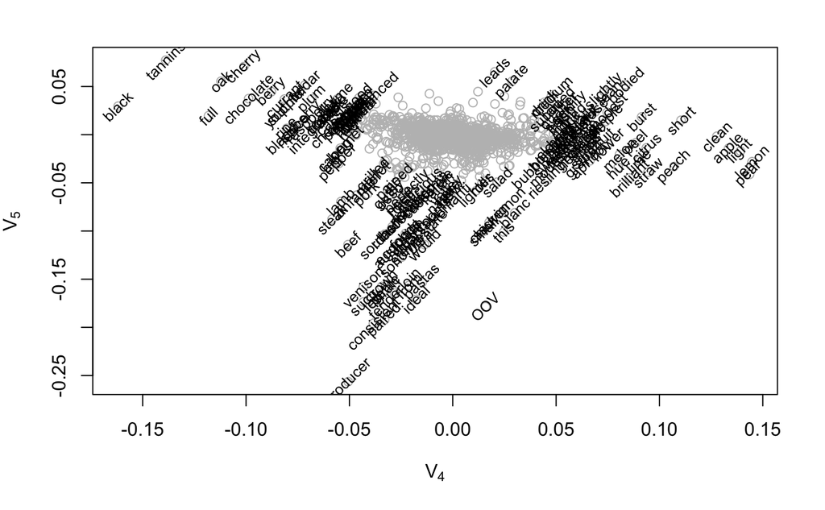

```r
plot(V[,4], V[,5], xlab= expression("V"[4]), ylab=expression("V"[5]), col='gray')
label <- 0.05 < sqrt(V[,4]^2 + V[,5]^2)    # pick those far from the origin
text(V[label,4], V[label,5], rownames(V)[label], cex=0.8, srt=45)
```

The function `plot_loadings` from the collection of R scripts in the file $\tt text\_utils.R$ automates this task. For example, there’s little evident reason to think that $V_2$ and $V_3$ would help distinguish the wine’s color.

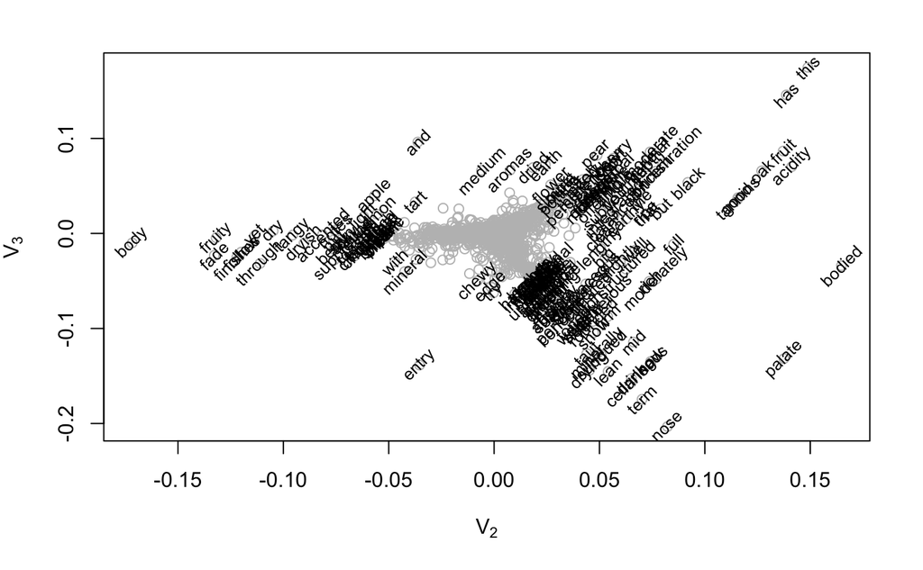

```r
plot_loadings(V, 2, 3, threshold=0.05, cex=0.8)
```

Before looking at scaling these methods up to larger amounts of data, what are those obvious clusters in the data? They are not related to color, and skimming the key words, don’t seem related to the variety either (e.g., cabernet versus zinfandel).

This plot reveals the answer. Gee, what do you think happened?

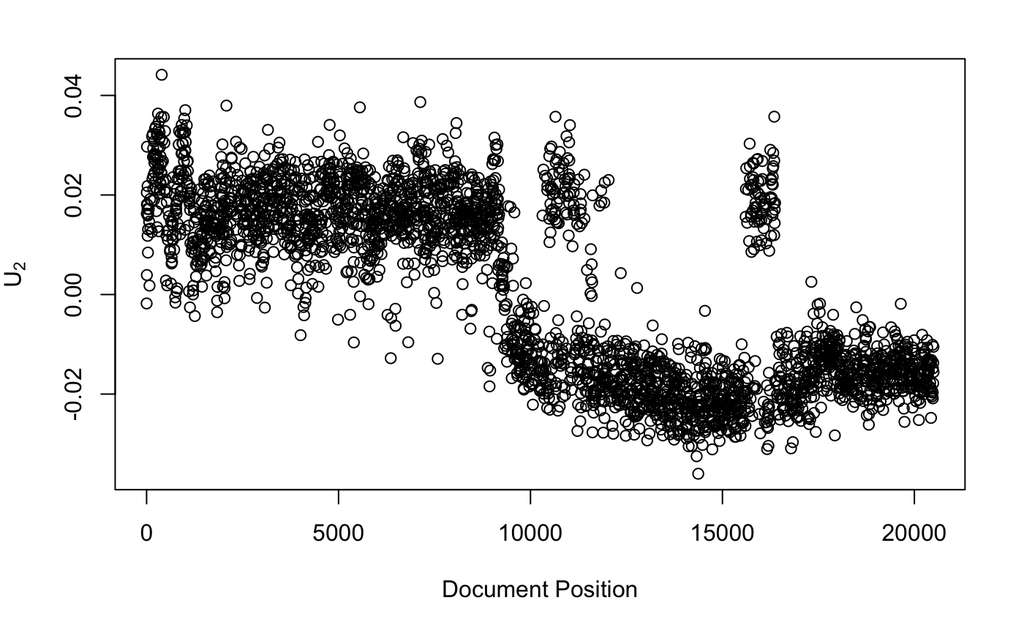

```r
plot(i.svd, U[,2], xlab="Document Position", ylab=expression("U"[2]))
```

```r
Wine$description[i.svd[U[,2]< -0.025]][1:5]
```

```
[1] "Aromas of banana cream pie, praline, and spicy poached pear follow through on a soft, supple entry to a dryish medium body with soft, quince and Meyer lemon cream notes. Finishes with a soft, melon and apple fade. Nice purity fruity and elegance, in an understated table friendly style."
[2] "Interesting aromas of buttercream, circus peanut, and pistachio brittle follow through on a very soft, gentle entry to a dryish medium body with cherry and green apple core notes. Finishes with a crisp, lemon and mild daikon radish accented fade. Different."
[3] "Toasty rice pudding and baked nectarine aromas follow through  on a soft supple entry to a dry-yet-fruity medium body with honeydew lime and smoky mineral notes. Finishes with a tangy toasted rice pilaf and like fade. Interesting."
[4] "Aromas of cotton candy and strawberries on angel food cake follow through on a lightly spritzy entry to a dryish medium body with tart green apples and peach skin notes. Finishes with a very crisp stony mineral, lemon, and praline accented fade. Pair with sautÃ©ed scallops with brown butter sau…
[5] "Cocoa dusted craisins, potter's clay, and raisin-fig chutney follow through on a lively, smooth entry to a tangy medium-to-full body with tangerine peel, menthol, and pomegranate accents. Finishes with a tart, refreshing cranberry chutney-like fade. A fun exciting to pair with spicy Asian pork …
```

And some of those from the other period. Do you notice any differences in the “style” of the review?

```r
Wine$description[i.svd[U[,2]> 0.025]][1:5]
```

```
[1] "Subdued, minerally nose. A lean entry leads to a drying, medium-bodied palate with grippy tannins. Structured and austere. Drink now."
[2] "Ripe black fruit aromas have a lavish-but-integrated chocolatey oak accent. A lush entry leads a rounded, full-bodied palate with velvety tannins. Drying, lengthy, balanced finish. An extremely well made PV that will work beautifully with roasted meats."
[3] "Perfumed, gamey dried fruit and leather aromas show a traditional range of complexities. A rich entry leads to a supple, moderately full-bodied palate with chewy tannins. A big, rounded style with a touch of wood on the grippy finish. Near- to mid-term cellar."
[4] "Austere, high toned mineral and citrus peel nose. A rich entry leads to a weighty, drying, moderately full-bodied palate with a ripe center. A very traditional style with good cut. Will blossom with mid-term cellaring."
[5] "Heavily Botrytised, heady caramel and molasses nose. A sharp entry leads to a racy, medium-bodied palate with intense sweetness and extremely concentrated dried fruit flavors. Quite youthful. This really needs mid-term cellaring and has the structure to age for two or three decades. Drink in sm…
```

# Random projection

We could use these variables to predict the colors of the other wines, but it would be nice to be able to compute the SVD for all of the data rather than just these 3000.

We can approximate the SVD of the entire document-term matrix using the method known as *random projection*. The key to the method is that if you only want, say 300 singular vectors, you can find them via random matrix multiplications. The function `random_projection_svd` (also in the $\tt text\_utils.R$ file) implements this algorithm.

To try to convince you it’s not magic, let’s compute the SVD via random projection and compare the results to what we get from `svd`. Random projection is quite a bit faster than the built-in function. The more power iterations the better, particulary for the terms associated with smaller singular values.

```r
set.seed(4843)   #  results depend on seed
rp_udv <- random_projection_svd(dtm.svd, d=50, power.iter=3, verbose=TRUE)
```

```
Starting power iterations...
Completed power iteration...
Completed power iteration...
Completed power iteration...
Completed QR factorization...
```

Like `svd`, this functions returns a named list of results.

```r
names(rp_udv)
```

```
[1] "d" "u" "v"
```

The larger singular values almost match those from the “exact” calculation.

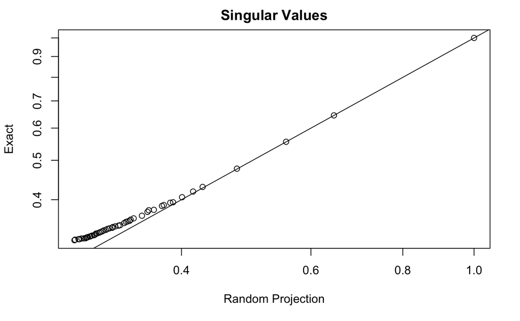

```r
plot(rp_udv$d, udv$d[1:50], log='xy',main="Singular Values",
      xlab="Random Projection", ylab="Exact")
abline(a=0,b=1)
```

As do the principal components.

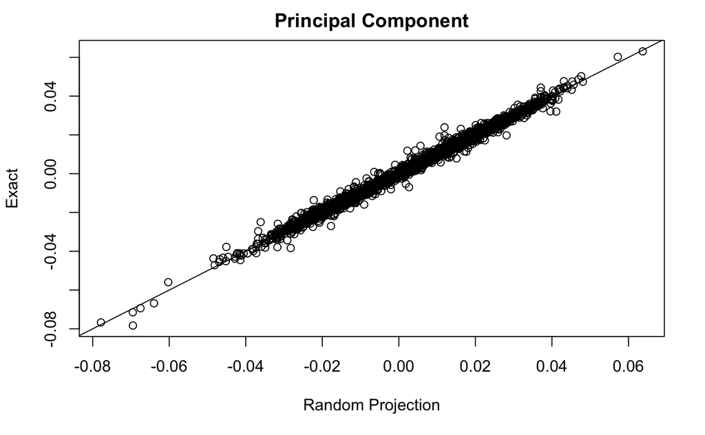

```r
plot(rp_udv$u[,4], udv$u[,4], main="Principal Component",
      xlab="Random Projection", ylab="Exact")
abline(a=0,b=1)
```

And the labels.

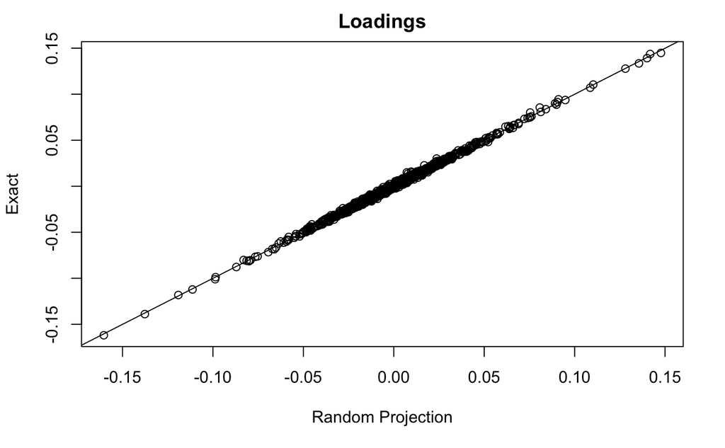

```r
plot(rp_udv$v[,4], udv$v[,4], main="Loadings",
      xlab="Random Projection", ylab="Exact")
abline(a=0,b=1)
```

To get the full decomposition, use `dtm.oov` rather than the sampled version (`dtm.svd`).

```r
set.seed(4843)   #  results depend on seed
rp_udv <- random_projection_svd(dtm.oov, d=50, power.iter=3, verbose=TRUE)
```

```
Starting power iterations...
Completed power iteration...
Completed power iteration...
Completed power iteration...
Completed QR factorization...
```